# Airbnb Analysis

Loc Dam

2022-11-22

```r
library(tidyverse)
```

```r
library(ggplot2)
library(plyr)
library(doParallel)
library(dplyr)
library(grid)

library(maps)
library(sf)
library(spData)
library(gridExtra)
library(maps)
library(corrplot)
library(viridis)
library(tm)
library(Metrics)
library(randomForest)
library(neuralnet)
library(wordcloud)
library(rpart.plot)
list.files(path = "../input")
```

```
## character(0)
```

**Load the data**

```r
states <- map_data("state")
```

```r
df <- read.csv("airbnb-listings.csv", sep = ";", header = T)
```

Let’s limnit our analyze region to only United States

```r
df <- df|>
  filter(Country == "United States")
  #mutate(price_per_night = round(Price/Minimum.Nights))|>
  #head(df,10)
tail(df, 2)
```

[output not shown]

[output cut: 62 more lines]

```
##        Review.Scores.Communication Review.Scores.Location Review.Scores.Value
## 134544                          10                      9                   9
## 134545                          NA                     NA                  NA
##        License Jurisdiction.Names Cancellation.Policy
## 134544                                         strict
## 134545                                       flexible
##        Calculated.host.listings.count Reviews.per.Month
## 134544                              1              0.23
## 134545                              1                NA
##                                  Geolocation
## 134544 30.246658830356882,-97.78398419366533
## 134545   30.2516986542039,-97.74109388414536
##                                                             Features
## 134544 Host Has Profile Pic,Host Identity Verified,Is Location Exact
## 134545                        Host Has Profile Pic,Is Location Exact
```

**Zero price listing**

```r
# remove values with price of $10 or lower
df <- df |>

  filter(Price > 10)|>
  mutate(price_per_night = round(Price/Minimum.Nights))|>
  filter(price_per_night > 10)
```

**Investigate the missing data**

Since this is a huge dataset, it is unadvoidably will have NA values. Let’s look at the last review, review_per_month and its NA values:

```r
df|>
  select(Last.Review, Reviews.per.Month) |>
    filter((is.na(Last.Review) & !is.na(Reviews.per.Month)) | (!is.na(Last.Review) & is.na(Reviews.per.Month))) |>
    dim()
```

```
## [1] 27396     2
```

**NA value in neighbourhood_group**

We notice there is a significantly large number in neighbourhood_group. count = 115845. We will group them and observe the abnormality.

```r
df |>
  group_by(Neighbourhood.Group.Cleansed) |>
  count()|>
  tail(1)
```

[output not shown]

[output cut: 15 more lines]

```
## 125274              90              365            2017-03-06                 0
##        First.Review Last.Review Review.Scores.Rating Review.Scores.Accuracy
## 125274                                            NA                     NA
##        Review.Scores.Cleanliness Review.Scores.Checkin
## 125274                        NA                    NA
##        Review.Scores.Communication Review.Scores.Location Review.Scores.Value
## 125274                          NA                     NA                  NA
##        License Jurisdiction.Names Cancellation.Policy
## 125274                                       flexible
##        Calculated.host.listings.count Reviews.per.Month
## 125274                              1                NA
##                                Geolocation
## 125274 30.2516986542039,-97.74109388414536
##                                      Features price_per_night freq
## 125274 Host Has Profile Pic,Is Location Exact             900    1
```

Now, let’s plot these neighbourhood_group on the map and observe its NA values.

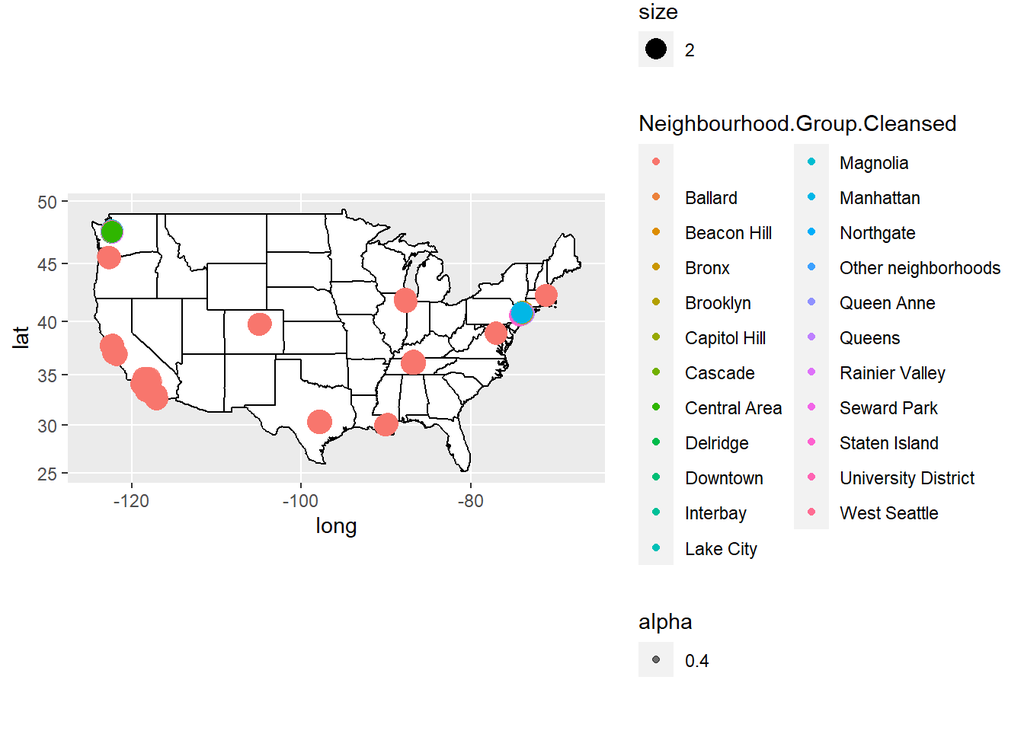

```r
df |>
    filter(Longitude > -140 & Latitude > 25) |>
    ggplot() +
    geom_polygon(data=states, fill = "white", aes(long, lat, group=group), colour = "black") +
    geom_point(aes(x=Longitude, y=Latitude, color=Neighbourhood.Group.Cleansed, size=2, alpha=0.4)) +
    coord_map()
```

```r
df = df |>
  mutate(neighbourhood_group = ifelse(Neighbourhood.Group.Cleansed == "Other Cities", "Other LA Cities", Neighbourhood.Group.Cleansed),
               neighbourhood_group = ifelse(Neighbourhood.Group.Cleansed == "Other neighborhoods", "Other Seattle neighbourhoods", Neighbourhood.Group.Cleansed),
               neighbourhood_group = ifelse(is.na(Neighbourhood.Group.Cleansed), "Other Cities", Neighbourhood.Group.Cleansed))
```

Take a glimpse at the data, we notice that there is no column of state, which is also a good factor needed to be analyze. Hence, let’s create a function that convert longtitude and latitude of each location into its state.

```r
lonlat_to_state <- function(pointsDF,
                            states = spData::us_states,
                            name_col = "NAME") {
    ## Convert points data.frame to an sf POINTS object
    pts <- st_as_sf(pointsDF, coords = 1:2, crs = 4326)

    ## Transform spatial data to some planar coordinate system
    ## (e.g. Web Mercator) as required for geometric operations
    states <- st_transform(states, crs = 3857)
    pts <- st_transform(pts, crs = 3857)

    ## Find names of state (if any) intersected by each point
    state_names <- states[[name_col]]
    ii <- as.integer(st_intersects(pts, states))
    state_names[ii]
}

lonlat_points <- data.frame(x =df$Longitude, y = df$Latitude)
df$state = lonlat_to_state(lonlat_points)
```

**Number listing per state**

Now, let’s have a look at number listing per state. I predict that the highly populated states like California and Newyork should be at the top of then list.

```r
number_of_listings_by_state <- aggregate(cbind(df$ID), by = list(state = df$state), FUN = length)
order_df<- number_of_listings_by_state[order(number_of_listings_by_state$V1, decreasing = TRUE),]
colnames(order_df)[2] = "Number of Listing by state"
head(order_df)
```

```
##                   state Number of Listing by state
## 1            California                      43481
## 9              New York                      37057
## 12                Texas                       9031
## 3  District of Columbia                       7169
## 5             Louisiana                       5203
## 4              Illinois                       4748
```

```r
removeRowsWithNA <- function(df, desiredCols) {
  completeVec <- complete.cases(df[, desiredCols])
  return(df[completeVec, ])
}
```

Indeed, our prediction is correct. Now, let’s visualize it

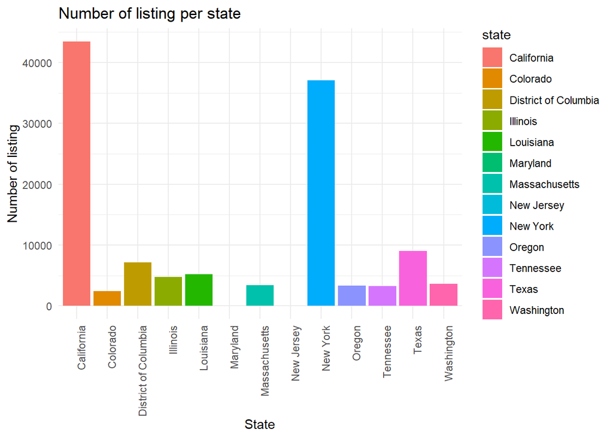

```r
p<- ggplot(number_of_listings_by_state, aes(x =state, y= V1, fill = state))+
  geom_bar(stat="identity")+
  theme_minimal()+
  xlab("State")+ ylab("Number of listing") + labs(title = "Number of listing per state")+
  theme(axis.text.x = element_text(angle = 90, hjust = 1))
p
```

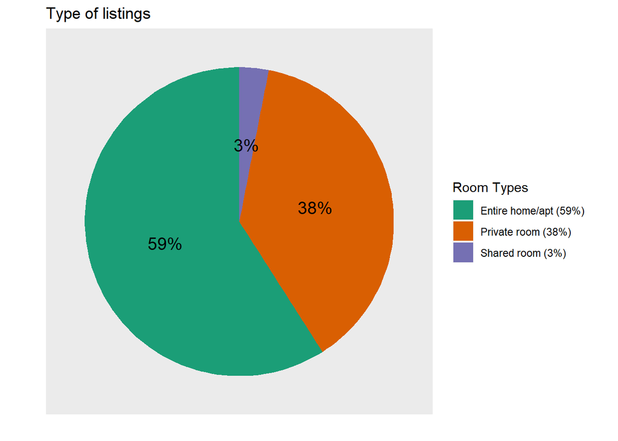

```r
# Get the room types and their percentages
room_types_counts <- table(df$Room.Type)
room_types <- names(room_types_counts)
counts <- as.vector(room_types_counts)
percentages <- scales::percent(round(counts/sum(counts), 2))
room_types_percentages <- sprintf("%s (%s)", room_types, percentages)
room_types_counts_df <- data.frame(group = room_types, value = counts)

# Plot
pie <- ggplot(room_types_counts_df, aes(x = "", y = value, fill = room_types_percentages))+
  geom_bar(width = 1, stat = "identity")+
  coord_polar("y", start = 0)+
  scale_fill_brewer("Room Types", palette = "Dark2")+
  ggtitle("Type of listings")+
  ylab("")+
  xlab("")+
  labs(fill="")+
  theme(axis.ticks = element_blank(), panel.grid = element_blank(), axis.text = element_blank())+
  geom_text(aes(label = percentages), size = 5, position = position_stack(vjust = 0.5))
pie
```

Most of listing is entire home or apartments. Private room also takes a significant portion. Meanwhile, the shared room plays a really small role in this.

One thing we can take away from this is that traveler prefer privacy at a high degree. That is why the investors focus on operating in entire home, apartment and private room. This is also a strong point of Airbnb versus the traditional hotel format where the staying locations are much more confined and exposed to public.

**Pricing**

Let’s analyze the most concerned factor of any business, Pricing. First, let start with the average pring per state. Since California and Newyork have the most listing, we believe that they should have the most affordable pricing since the high competition in such crowded states.

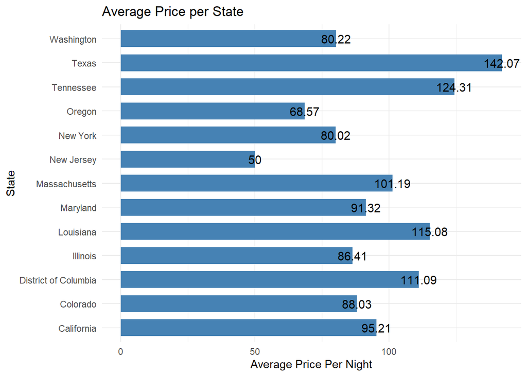

```r
# Calculate the average price per state
average_prices_per_state <- aggregate(cbind(df$price_per_night),
                  by = list(state = df$state),
                  FUN = function(x) mean(x))

# Plot
ggplot(data = average_prices_per_state, aes(x = average_prices_per_state$state, y = average_prices_per_state$V1))+
    geom_bar(stat = "identity", fill = "steelblue", width = 0.7)+
    geom_text(aes(label = round(average_prices_per_state$V1, 2)), size=4)+
    coord_flip()+
    xlab("State")+
    ylab("Average Price Per Night")+
  labs(title = "Average Price per State") +
    theme_minimal()
```

```r
highest_price_per_night <- df |>
  group_by(state)|>
  select(state, price_per_night,Price,  Minimum.Nights)|>
  filter(Price == max(Price), state != "NA")
  #mutate(price_per_night = price/minimum_nights)

highest_price_per_night<-distinct(highest_price_per_night)
highest_price_per_night
```

```
## # A tibble: 28 × 4
## # Groups:   state [13]
##    state                price_per_night Price Minimum.Nights
##    <chr>                          <dbl> <int>          <int>
##  1 Louisiana                        999   999              1
##  2 Texas                            333   999              3
##  3 District of Columbia             500   999              2
##  4 Louisiana                        500   999              2
##  5 California                       999   999              1
##  6 California                       200   999              5
##  7 California                       333   999              3
##  8 Massachusetts                    999   999              1
##  9 Colorado                         498   995              2
## 10 Texas                            999   999              1
## # ℹ 18 more rows
```

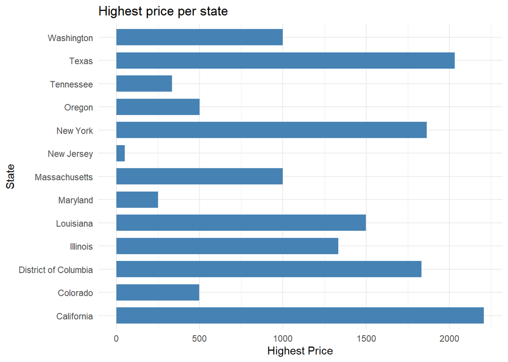

```r
ggplot(data = highest_price_per_night, aes(x = highest_price_per_night$state, y = highest_price_per_night$price_per_night))+
    geom_bar(stat = "identity", fill = "steelblue", width = 0.7)+
    #geom_text(aes(label = round(highest_price_per_night$price_per_night, 2)), size=4)+
    coord_flip()+
    xlab("State")+
    ylab("Highest Price")+
    labs(title = "Highest price per state")+
    theme_minimal()
```

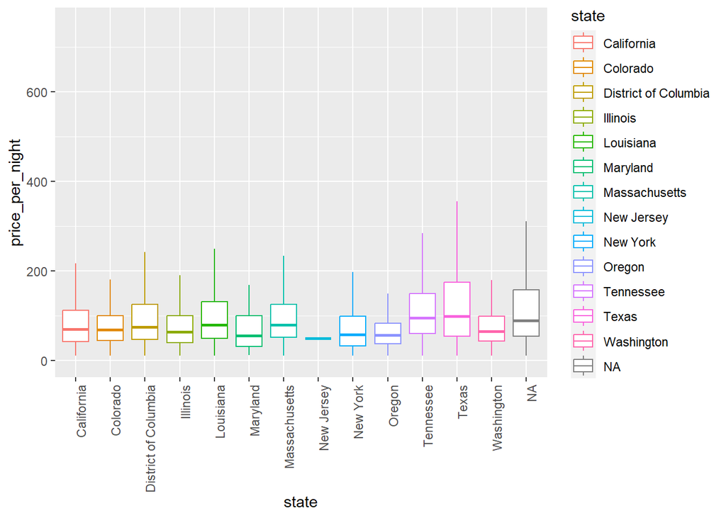

```r
ggplot(data = df, aes(x = state, y = price_per_night, color = state)) +
  geom_boxplot(outlier.shape = NA) +
  theme(axis.text.x = element_text(angle = 90, hjust = 1))+
  coord_cartesian(ylim = c(0, 750))
```

Let’s investigate the relation between number of reviews and its pricing.

```r
df|>
  select(Name, Number.of.Reviews, price_per_night)|>
  arrange(desc(Number.of.Reviews))|>
  tail()
```

```
##                                        Name Number.of.Reviews price_per_night
## 125269        2 beds available near Domain!                 0             250
## 125270 Quite apartment near shopping center                 0             100
## 125271  Home Away From Home, Chic and Comfy                 0             237
## 125272         Spacious remodeled 3/2 condo                 0              90
## 125273              Forest- Great for SXSW!                 0             122
## 125274      Vintage Travis Hieghts Bungalow                 0             900
```

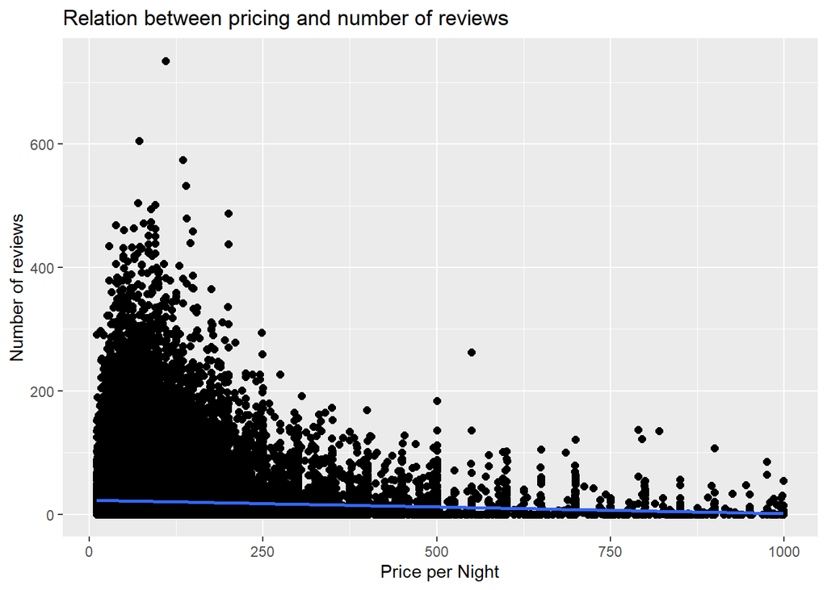

```r
p1<-ggplot(df, aes(x = price_per_night, y = Number.of.Reviews )) +
  geom_point( size = 2)+
  geom_smooth(method = lm, se = FALSE)+
  labs(title = "Relation between pricing and number of reviews")+
  ylab("Number of reviews")+
  xlab("Price per Night")
p1
```

As we notice, on the lower range of price, which means they are more affordable. This leads to these listing have more reviews.

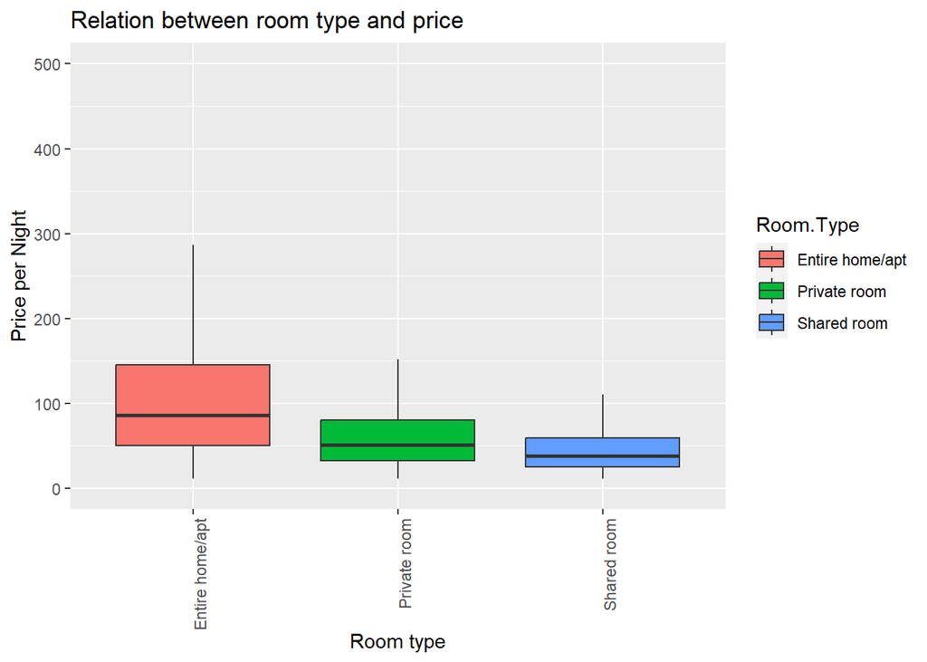

```r
ggplot(data = df, aes(x = Room.Type, y = price_per_night,fill=Room.Type)) +
  geom_boxplot(outlier.shape = NA) +theme(axis.text.x = element_text(angle = 90, hjust = 1)) +coord_cartesian(ylim = c(0, 500))+
  xlab("Room type")+ ylab("Price per Night")+ labs(title = "Relation between room type and price")
```

This also consistent with our observation so far where the Entire home should takes the most percentage as well as the highest average value.

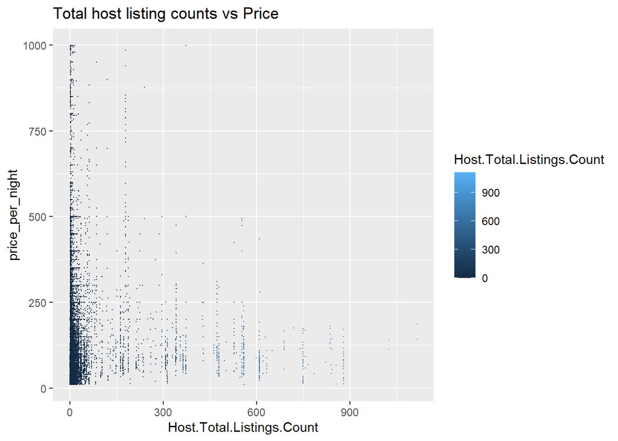

```r
ggplot(data = df, aes(x = Host.Total.Listings.Count , y = price_per_night, color=Host.Total.Listings.Count )) +geom_point(size=0.1) +
  labs(title = "Total host listing counts vs Price")
```

Let’s look at the distribution of property type.

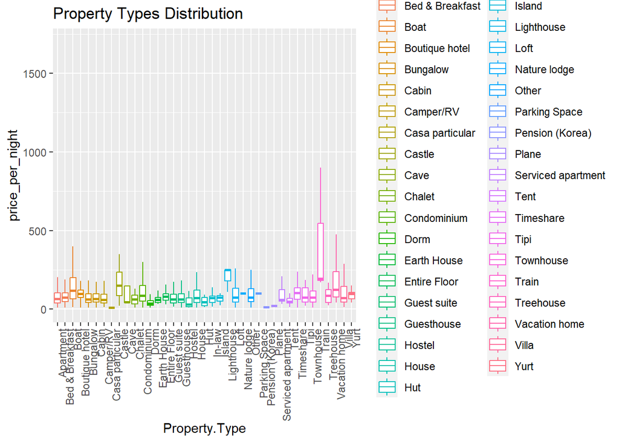

```r
df_no_NA <-subset(df,Property.Type != "N/A" & Property.Type != "")

ggplot(data = df_no_NA, aes(x = Property.Type, y = price_per_night,color=Property.Type)) +geom_boxplot(outlier.shape = NA) +theme(axis.text.x = element_text(angle = 90, hjust = 1)) +coord_cartesian(ylim = c(0, 1700))+
  labs(title = "Property Types Distribution")
```

```r
city_to_state <- df |>
  group_by(City, state) |>
    count() |>
    filter(!is.na(state)) |>
    arrange(City) |>
    ungroup() |>
    distinct(City, .keep_all=TRUE) |>
    select(City, state)
```

```r
df_city <- df |> left_join(city_to_state, by="City", suffix=c("_sf", "_imputed"))

# creating a unified state field based on the simple features value if present and the imputed value otherwise
df_city <- df_city |>
  mutate(state = ifelse(is.na(state_sf), state_imputed, state_sf)) |>
  select(-state_sf, -state_imputed)
head(df_city, 2)
```

[output not shown]

[output cut: 65 more lines]

```
##   Review.Scores.Location Review.Scores.Value License      Jurisdiction.Names
## 1                     NA                  NA         City of Los Angeles, CA
## 2                     NA                  NA         City of Los Angeles, CA
##   Cancellation.Policy Calculated.host.listings.count Reviews.per.Month
## 1            flexible                              1                NA
## 2            flexible                              1                NA
##                              Geolocation
## 1  34.14775649234191,-118.59133780081316
## 2 34.164597238320674,-118.60051225075456
##                                                        Features price_per_night
## 1                        Host Has Profile Pic,Is Location Exact             150
## 2 Host Has Profile Pic,Host Identity Verified,Is Location Exact              88
##   neighbourhood_group      state
## 1                     California
## 2                     California
```

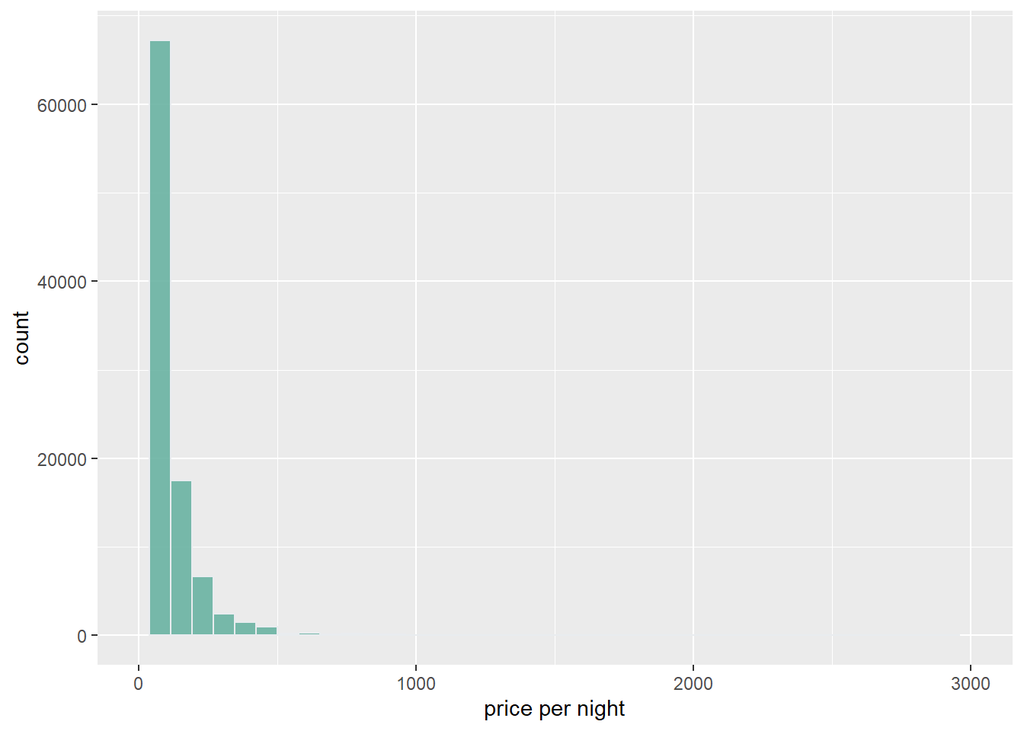

```r
df_city |>
    ggplot(aes(x=price_per_night)) +
    geom_histogram(bins=40, fill="#69b3a2", color="#e9ecef", alpha=0.9) +
    xlim(0, 3000) + xlab("price per night")
```

```r
    ggtitle("Distribution of AirBnb Prices in US Dataset")
```

```
## $title
## [1] "Distribution of AirBnb Prices in US Dataset"
##
## attr(,"class")
## [1] "labels"
```

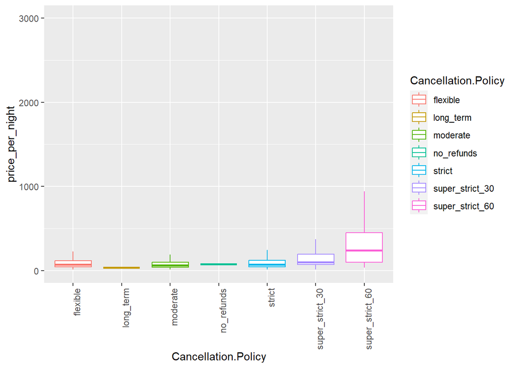

```r
ggplot(data = df, aes(x = Cancellation.Policy, y = price_per_night,color=Cancellation.Policy)) +
  geom_boxplot(outlier.shape = NA) +
  theme(axis.text.x = element_text(angle = 90, hjust = 1)) +
  coord_cartesian(ylim = c(0, 3000))
```

```r
# create copy of dataset
data_clean <- df

# remove values with price of $10 or lower
data_clean <- data_clean %>% filter(price_per_night > 10)

# get rid of the top 5% percentile of prices in each city
data_clean = data_clean %>%
    group_by(City) %>%
    mutate(price_percentile = rank(price_per_night, ties.method="first") / length(price_per_night)) %>%
    filter(price_percentile < 0.9) %>%
    ungroup()
```

```r
top_states <- number_of_listings_by_state|>
  arrange(desc(V1))|>
  head(7)
top_states
```

```
##                  state    V1
## 1           California 43481
## 2             New York 37057
## 3                Texas  9031
## 4 District of Columbia  7169
## 5            Louisiana  5203
## 6             Illinois  4748
## 7           Washington  3657
```

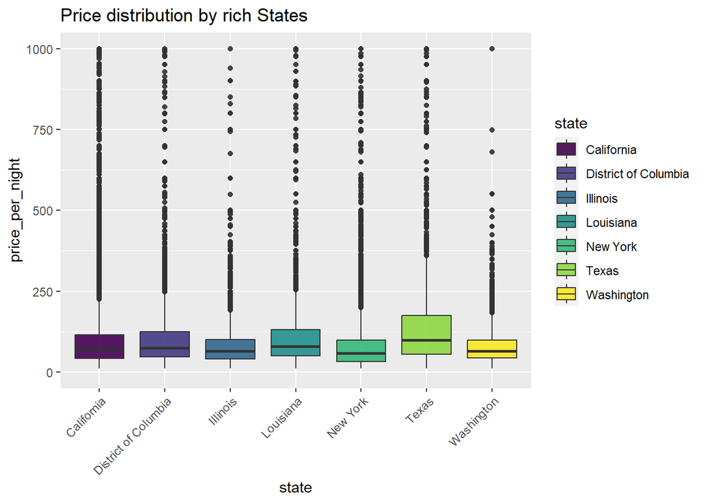

```r
df_city %>% filter(state %in% top_states$state) %>%
    ggplot(aes(x=state, y=price_per_night, fill=state)) +
    geom_boxplot(alpha=0.9) +
    ylim(0, 1000) +
    ggtitle("Price distribution by rich States")  +
    theme(axis.text.x=element_text(angle=45, hjust=1)) +
    scale_fill_viridis_d()
```

This is also suspicious - why are New York Airbnbs cheaper than other states? Potentially, this could be down to the types of rooms on offer.

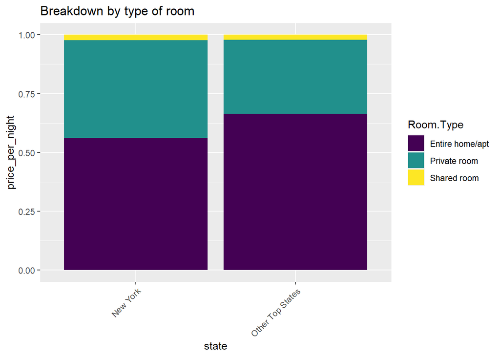

```r
data_clean %>% filter(state %in% top_states$state) %>%

    mutate(state = ifelse(state == "New York", "New York", "Other Top States"))  %>%
    ggplot(aes(x=state, y=price_per_night, fill=Room.Type, order = (Room.Type) )) +
    geom_bar(position = position_fill(reverse = TRUE), stat = "identity") +
    ggtitle("Breakdown by type of room")  +
    theme(axis.text.x=element_text(angle=45, hjust=1)) +
    scale_fill_viridis_d()
```

**Review analysis**

```r
colnames(df)
```

```
##  [1] "ID"                             "Listing.Url"
##  [3] "Scrape.ID"                      "Last.Scraped"
##  [5] "Name"                           "Summary"
##  [7] "Space"                          "Description"
##  [9] "Experiences.Offered"            "Neighborhood.Overview"
## [11] "Notes"                          "Transit"
## [13] "Access"                         "Interaction"
## [15] "House.Rules"                    "Thumbnail.Url"
## [17] "Medium.Url"                     "Picture.Url"
## [19] "XL.Picture.Url"                 "Host.ID"
## [21] "Host.URL"                       "Host.Name"
## [23] "Host.Since"                     "Host.Location"
## [25] "Host.About"                     "Host.Response.Time"
## [27] "Host.Response.Rate"             "Host.Acceptance.Rate"
## [29] "Host.Thumbnail.Url"             "Host.Picture.Url"
```

[output cut: 31 more lines]

```r
scores <- c("Review.Scores.Rating","Review.Scores.Accuracy","Review.Scores.Cleanliness","Review.Scores.Checkin","Review.Scores.Communication","Review.Scores.Location","Review.Scores.Value")
scores_data <- df[scores]
scores_data <- removeRowsWithNA(scores_data, scores)
```

```r
library(cowplot)
library(gridExtra)
```

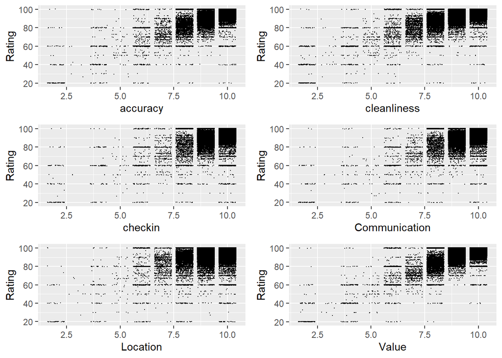

```r
a <-ggplot(data = scores_data, aes(x = Review.Scores.Accuracy, y = Review.Scores.Rating )) +
  geom_jitter(size = 0.1) + xlab("accuracy") +ylab("Rating")

b <- ggplot(data = scores_data, aes(x = Review.Scores.Cleanliness, y = Review.Scores.Rating )) +
  geom_jitter(size = 0.1)   + xlab("cleanliness") +ylab("Rating")
c <- ggplot(data = scores_data, aes(x = Review.Scores.Checkin, y = Review.Scores.Rating )) +
  geom_jitter(size = 0.1)+ xlab("checkin") +ylab("Rating")

d <-  ggplot(data = scores_data, aes(x = Review.Scores.Communication, y = Review.Scores.Rating )) +
  geom_jitter(size = 0.1)+ xlab("Communication") +ylab("Rating")

e <- ggplot(data = scores_data, aes(x = Review.Scores.Location, y = Review.Scores.Rating )) +
  geom_jitter(size = 0.1)+ xlab("Location") +ylab("Rating")

f <-  ggplot(data = scores_data, aes(x = Review.Scores.Value, y = Review.Scores.Rating )) +
  geom_jitter(size = 0.1)+ xlab("Value")+ylab("Rating")

grid.arrange(a, b, c, d, e, f , ncol = 2, nrow = 3)
```

From the plots, we can see that most of the people who give the listings high ratings, give high scores for all the other types of scores (denser in right top corners).

**Host behaviors vs Price**

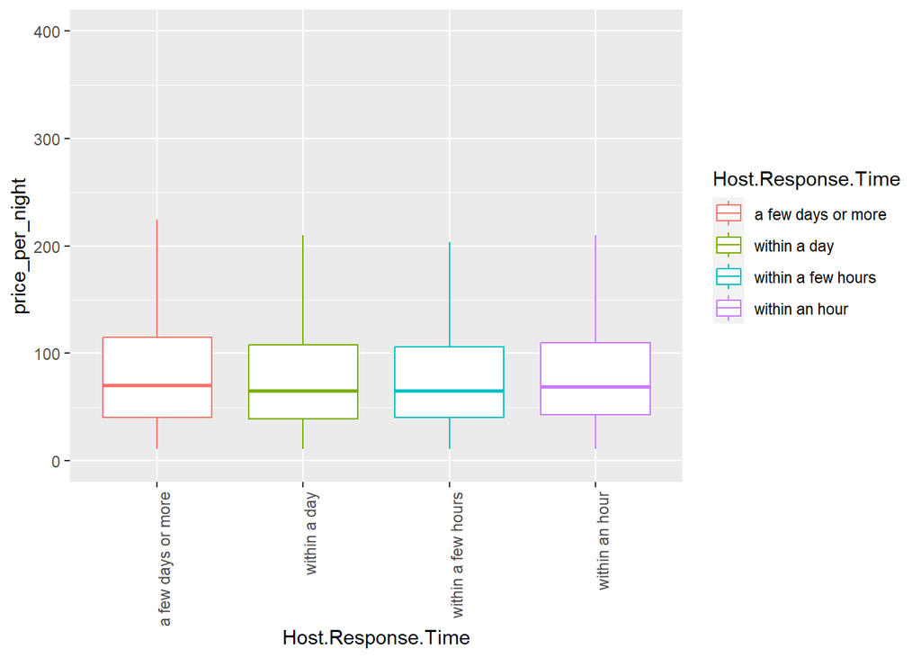

```r
df_no_NA <-subset(df,Host.Response.Time != "N/A" & Host.Response.Time != "")
ggplot(data = df_no_NA, aes(x = Host.Response.Time, y = price_per_night,color=Host.Response.Time))+
  geom_boxplot(outlier.shape = NA) +
  theme(axis.text.x = element_text(angle = 90, hjust = 1))+coord_cartesian(ylim = c(0, 400))
```

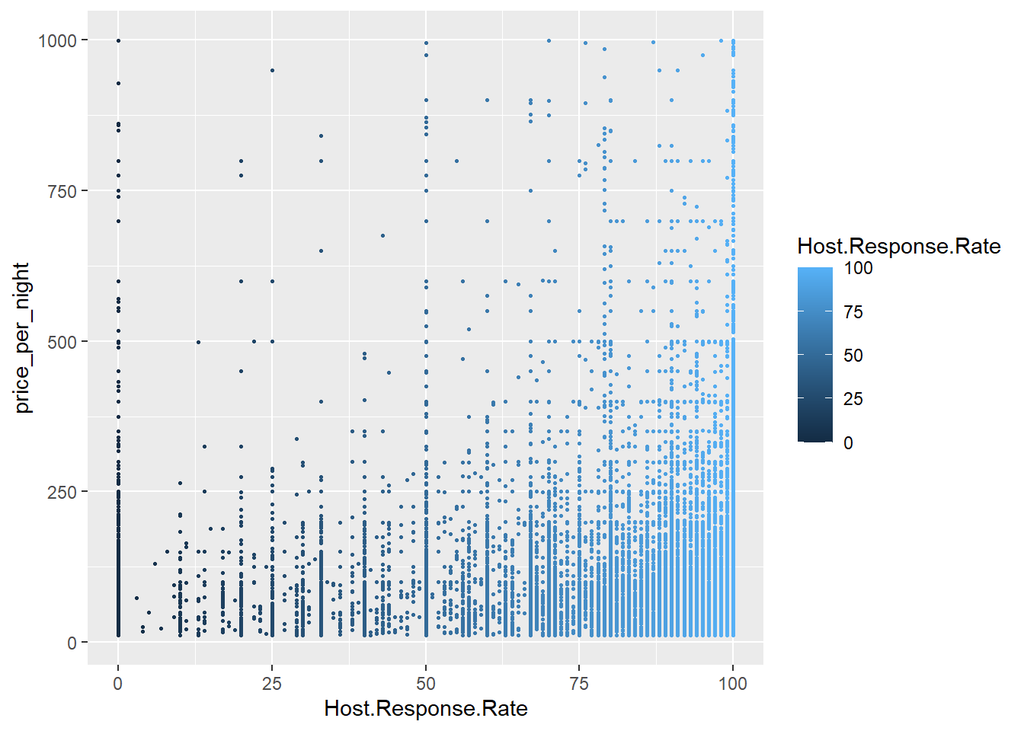

```r
ggplot(data = df, aes(x = Host.Response.Rate, y = price_per_night, color=Host.Response.Rate)) +
  geom_point(size=0.5)
```

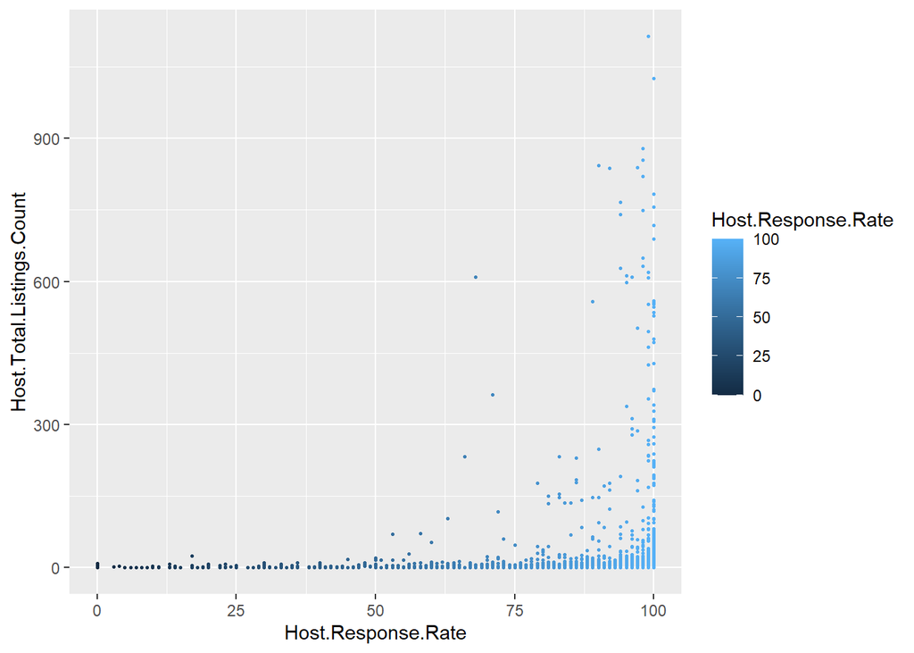

```r
ggplot(data = df, aes(x = Host.Response.Rate, y = Host.Total.Listings.Count, color=Host.Response.Rate)) +
  geom_point(size=0.5)
```

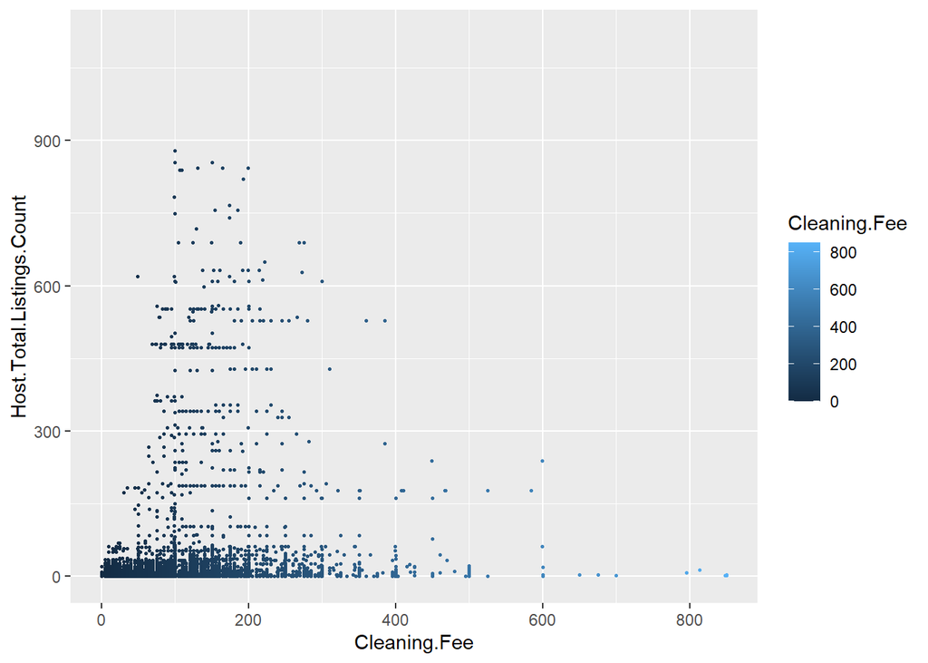

```r
ggplot(data = df, aes(x = Cleaning.Fee, y = Host.Total.Listings.Count, color=Cleaning.Fee)) +
  geom_point(size=0.5)
```

**Modeling and Prediction**

**Relationship between ratings.**

Let’s start with a basic model linear regression between all the rating reviews.

```r
rating_regression <- lm(data=df, Review.Scores.Rating~Review.Scores.Accuracy+Review.Scores.Cleanliness+Review.Scores.Checkin+Review.Scores.Communication+Review.Scores.Location+Review.Scores.Value)
summary(rating_regression)
```

```
##
## Call:
## lm(formula = Review.Scores.Rating ~ Review.Scores.Accuracy +
##     Review.Scores.Cleanliness + Review.Scores.Checkin + Review.Scores.Communication +
##     Review.Scores.Location + Review.Scores.Value, data = df)
##
## Residuals:
##    Min     1Q Median     3Q    Max
## -58.04  -1.72   0.28   1.28  46.66
##
## Coefficients:
##                             Estimate Std. Error t value Pr(>|t|)
## (Intercept)                 -6.14158    0.23937  -25.66   <2e-16 ***
## Review.Scores.Accuracy       2.20828    0.02414   91.46   <2e-16 ***
## Review.Scores.Cleanliness    2.21864    0.01786  124.24   <2e-16 ***
## Review.Scores.Checkin        0.99444    0.02868   34.68   <2e-16 ***
## Review.Scores.Communication  1.64802    0.02976   55.38   <2e-16 ***
## Review.Scores.Location       0.77998    0.01895   41.15   <2e-16 ***
## Review.Scores.Value          2.63684    0.02298  114.77   <2e-16 ***
## ---
## Signif. codes:  0 '***' 0.001 '**' 0.01 '*' 0.05 '.' 0.1 ' ' 1
##
## Residual standard error: 3.906 on 96150 degrees of freedom
##   (29117 observations deleted due to missingness)
## Multiple R-squared:  0.7344, Adjusted R-squared:  0.7343
## F-statistic: 4.43e+04 on 6 and 96150 DF,  p-value: < 2.2e-16
```

The model has good p-value (<2.2e-16). All the factors are significant. Let’s plot this and observe its behavior:

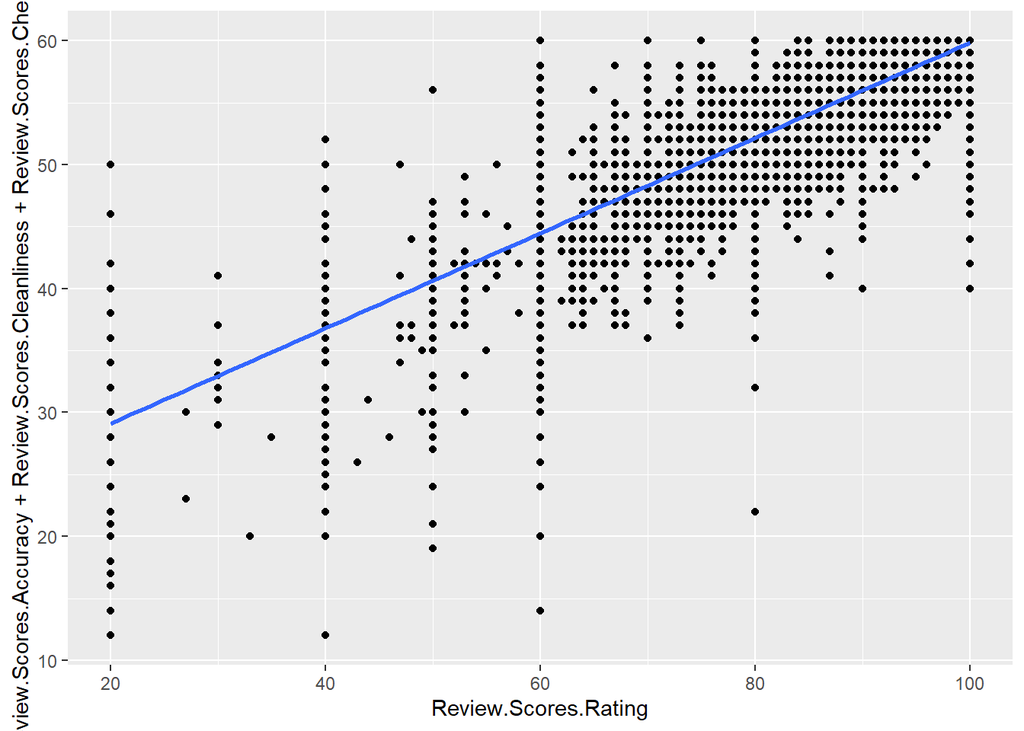

```r
ggplot(data = rating_regression, aes(Review.Scores.Rating,Review.Scores.Accuracy+Review.Scores.Cleanliness+Review.Scores.Checkin+Review.Scores.Communication+Review.Scores.Location+Review.Scores.Value)) +
  geom_point()+
  geom_smooth(method = 'lm')
```

Let’s plot more plots to see clearer the relationship.

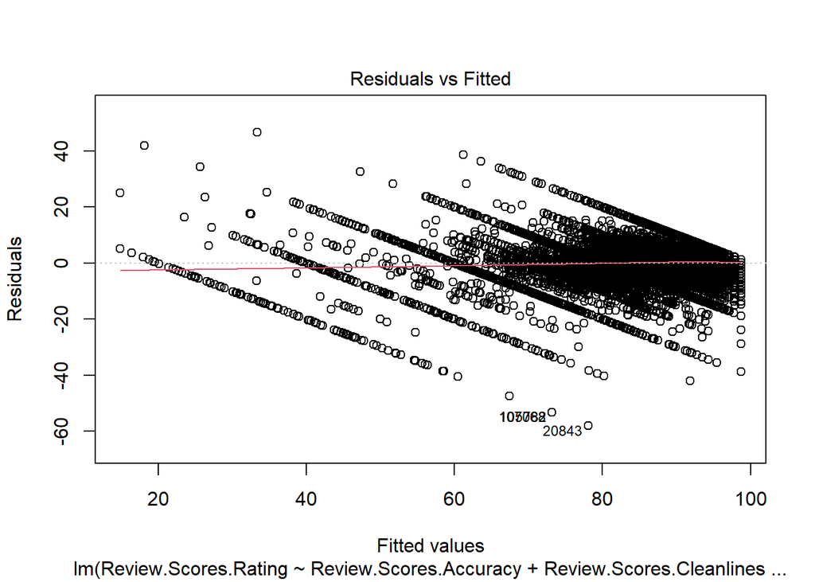

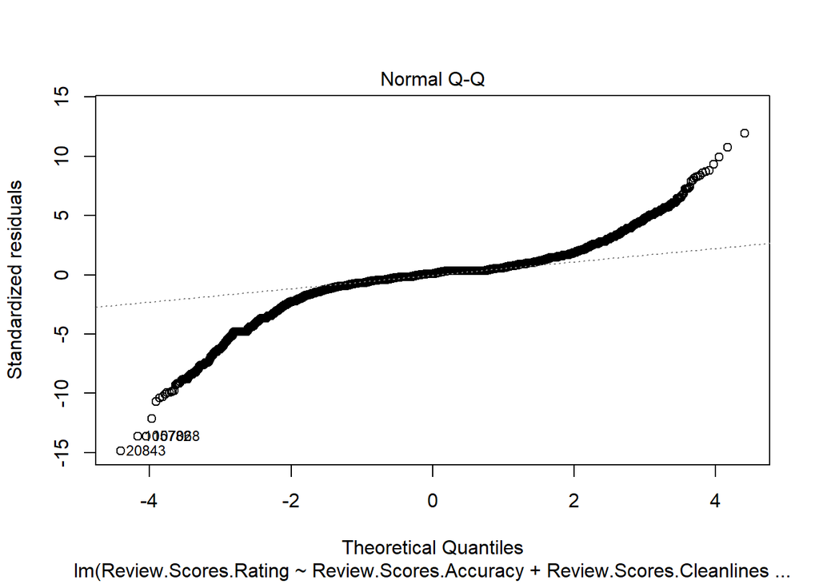

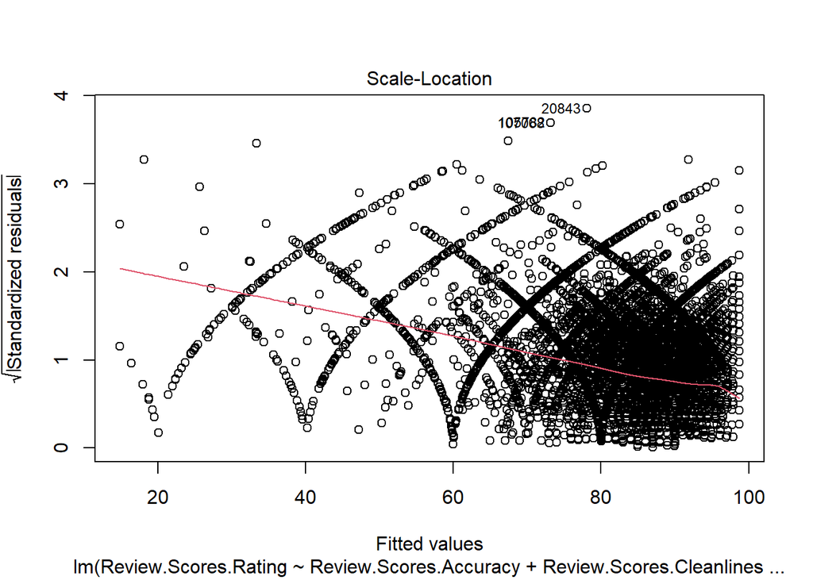

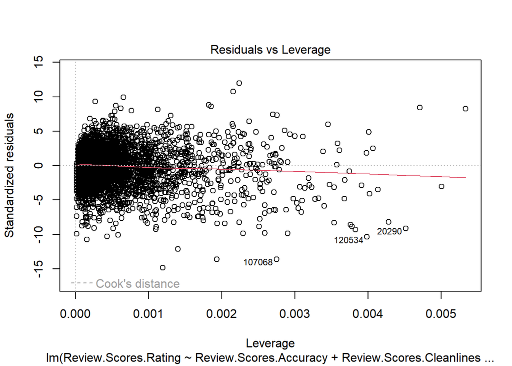

```r
plot(rating_regression)
```

The “Normal Q-Q” plot shows if residuals are normally distributed. Our residuals are not well lined on the straight dashed line except in the middle of the plot, which is not quite good.

The “Scale-Location” plot lets us check the assumption of equal variance. Our line is not horizontal with randomly spread points, thus, our residuals are not homoscedastic. This was expected, since from the previous plots of the different types of ratings, we could clearly see that the variance depends on the score.

**Relation between Price and its factors**

```r
price_regression <- p_reg1 <- lm(data=df, price_per_night~Host.Response.Rate+Host.Acceptance.Rate+Host.Total.Listings.Count+Property.Type+Room.Type+Accommodates+Bathrooms+Bedrooms+Beds+Bed.Type+Square.Feet+Security.Deposit+Cleaning.Fee+Extra.People+Minimum.Nights+Maximum.Nights+Number.of.Reviews+Cancellation.Policy+State)
summary(price_regression)
```

```
##
## Call:
## lm(formula = price_per_night ~ Host.Response.Rate + Host.Acceptance.Rate +
##     Host.Total.Listings.Count + Property.Type + Room.Type + Accommodates +
##     Bathrooms + Bedrooms + Beds + Bed.Type + Square.Feet + Security.Deposit +
##     Cleaning.Fee + Extra.People + Minimum.Nights + Maximum.Nights +
##     Number.of.Reviews + Cancellation.Policy + State, data = df)
##
## Residuals:
##     Min      1Q  Median      3Q     Max
## -149.54  -32.08   -7.00   15.27  660.64
##
## Coefficients:
##                                      Estimate Std. Error t value Pr(>|t|)
## (Intercept)                         1.196e+02  3.929e+01   3.043 0.002424 **
## Host.Response.Rate                 -4.497e-01  2.087e-01  -2.155 0.031473 *
## Host.Acceptance.Rate0%             -2.236e+01  2.994e+01  -0.747 0.455494
## Host.Acceptance.Rate100%           -1.250e+01  1.225e+01  -1.020 0.307830
## Host.Acceptance.Rate31%            -4.929e+00  7.127e+01  -0.069 0.944879
## Host.Acceptance.Rate33%             2.008e+01  5.179e+01   0.388 0.698378
## Host.Acceptance.Rate50%            -3.879e+01  3.678e+01  -1.055 0.291932
## Host.Acceptance.Rate56%            -2.652e+01  4.688e+01  -0.566 0.571762
## Host.Acceptance.Rate58%            -4.789e+01  7.139e+01  -0.671 0.502491
## Host.Acceptance.Rate63%            -1.775e+02  7.829e+01  -2.267 0.023666 *
## Host.Acceptance.Rate67%            -2.678e+01  5.262e+01  -0.509 0.610953
## Host.Acceptance.Rate68%             2.500e+02  7.112e+01   3.515 0.000466 ***
## Host.Acceptance.Rate71%             5.685e+00  3.680e+01   0.154 0.877262
## Host.Acceptance.Rate75%            -5.647e+01  7.122e+01  -0.793 0.428049
## Host.Acceptance.Rate76%            -1.094e+01  5.050e+01  -0.217 0.828477
## Host.Acceptance.Rate78%            -5.153e+00  5.420e+01  -0.095 0.924282
## Host.Acceptance.Rate80%            -4.977e+01  7.091e+01  -0.702 0.482950
## Host.Acceptance.Rate82%            -9.241e-01  7.137e+01  -0.013 0.989672
## Host.Acceptance.Rate83%            -9.152e+00  5.119e+01  -0.179 0.858156
## Host.Acceptance.Rate86%            -6.195e+01  4.235e+01  -1.463 0.143968
## Host.Acceptance.Rate87%            -6.780e+01  6.196e+01  -1.094 0.274146
## Host.Acceptance.Rate88%            -5.438e+01  4.188e+01  -1.299 0.194508
## Host.Acceptance.Rate89%             5.936e+01  7.140e+01   0.831 0.405997
## Host.Acceptance.Rate90%             4.168e+00  7.112e+01   0.059 0.953290
## Host.Acceptance.Rate91%            -1.037e+02  3.329e+01  -3.115 0.001912 **
## Host.Acceptance.Rate92%            -4.572e+01  3.933e+01  -1.162 0.245411
```

[output cut: 42 more lines]

```
## StateIL                            -2.643e+01  2.042e+01  -1.294 0.196036
## StateLA                            -5.269e+00  1.248e+01  -0.422 0.673024
## StateMA                             4.763e+00  2.836e+01   0.168 0.866689
## StateNY                            -1.903e+01  7.348e+00  -2.589 0.009805 **
## StateOR                            -1.806e+01  1.889e+01  -0.956 0.339312
## StateTN                             4.683e+01  2.975e+01   1.574 0.115879
## StateTX                             1.281e+01  8.985e+00   1.426 0.154205
## StateWA                            -1.308e+01  1.583e+01  -0.826 0.408812
## ---
## Signif. codes:  0 '***' 0.001 '**' 0.01 '*' 0.05 '.' 0.1 ' ' 1
##
## Residual standard error: 70.52 on 752 degrees of freedom
##   (124446 observations deleted due to missingness)
## Multiple R-squared:  0.4537, Adjusted R-squared:  0.3992
## F-statistic: 8.328 on 75 and 752 DF,  p-value: < 2.2e-16
```

For this model, we have good p-value (<2.2e-16) with good R-squred (0.4537).

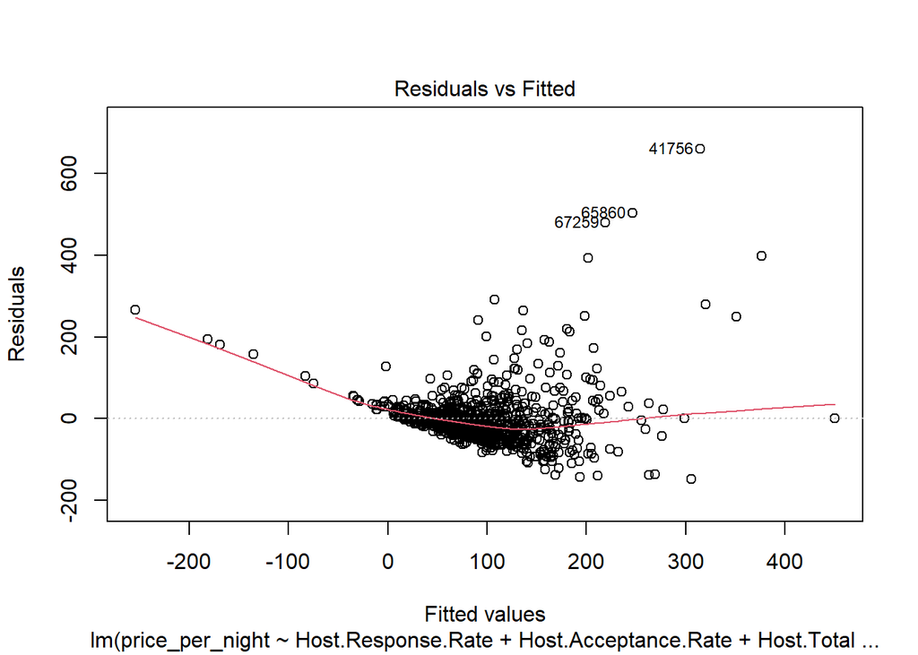

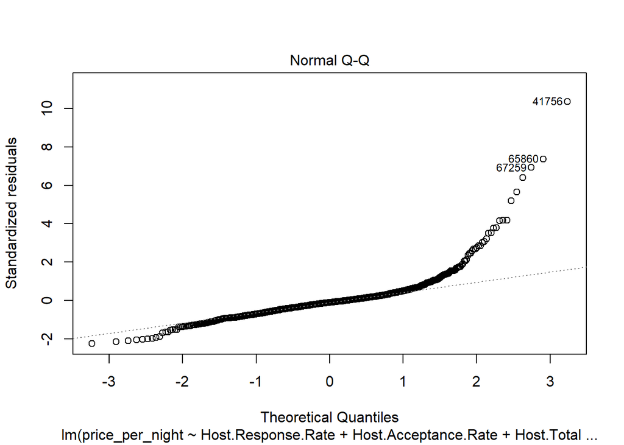

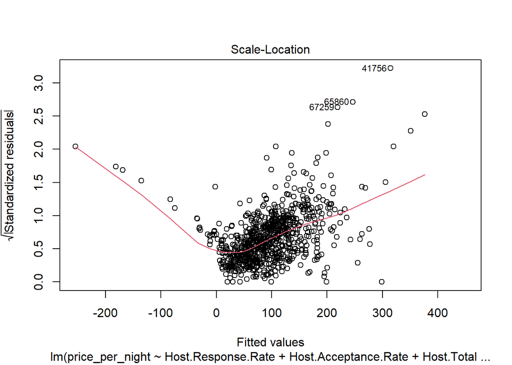

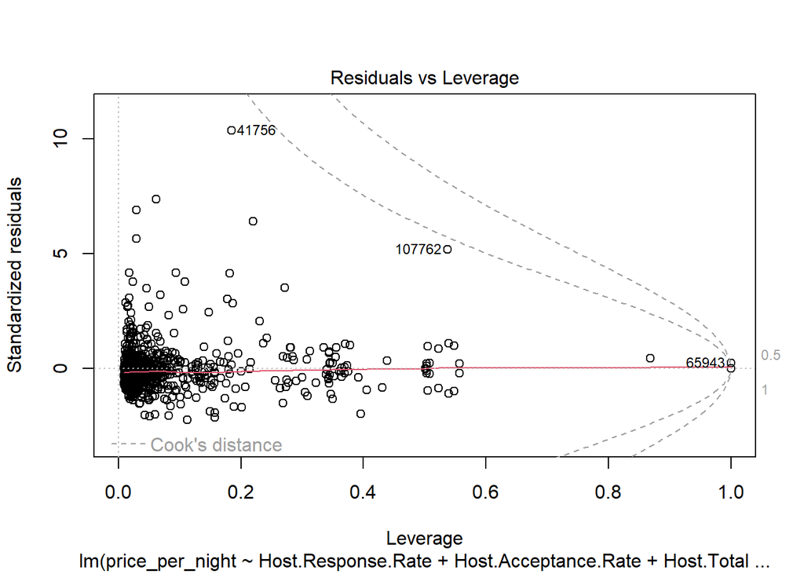

```r
plot(price_regression)
```